# DS 6306 Final Project 2

Oluwadamilola Owolabi

2024-04-22

#Helpful Links

Please try out my Rshinyapp in order to experience my model’s prediction rate : https://oluwadamilolaowolabi.shinyapps.io/DS_6372_Project_2/

Heres a Youtube Link to my presentation: https://youtu.be/hwyr3ZPVgIQ

## INTRODUCTION

Good afternoon Mr. Steven Williams – CEO and Mrs. Christy Jacoby - CFO. I am here today to present my findings on my analysis on the factors affecting the rate of attrition among employees within a company. I am an employee of DDSAnalytivs, and i am here to present how my analysis can help you retain talented employees within Frito Lays.

Our data set was extracted from the company’s AWS bucket. Where we interviewed 870 random employees, question related to their possibility of attrition.We got 36 answers from each employee. 34 of those factors (answers) were used for our dependent variables. hle 2 of them were used for our predictions: The monthly income for our Regression prediction, and the Attrition for our Classification prediction.

My aim is to provide valuable insight on what factors affects attrition rate and Monthly Income

## LOADING LIBRARIES

```r
library(ggplot2) #For data visualization
library(dplyr)  # For data manipulation
library(tidyverse)
#install.packages('aws.s3')
library(aws.s3) #to access the aws s3 package
library(caret) # Load the caret package
library(pROC) # for the ROC curve
library(class) #calling the knn function
library(e1071)  # for naiveBayes function
```

## GETTING THE CSV FILE FROM AWS USING AWS.S3 PACKAGES

```r
Sys.setenv("AWS_ACCESS_KEY_ID" = "AKIASXWFQWBV2AEG7EEN",
           "AWS_SECRET_ACCESS_KEY" = "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",
           "AWS_DEFAULT_REGION" = "us-east-2")


# Using aws.s3
aws.s3::bucketlist()
```

```
##        Bucket             CreationDate
## 1 ds6306fls13 2024-04-03T00:47:17.000Z
```

```r
aws.s3::get_bucket("msdsds6306")
```

[output not shown]

[output cut: 26 more lines]

```
## $Contents
## Key:            iris.csv
## LastModified:   2023-11-15T00:11:09.000Z
## ETag:           "885a41d063a7923ae8d0e8404d9291a3"
## Size (B):       4821
## Owner:          15a554773c0d84536ce02c70d7513a1db00372e75f2bcebece99b2bd3cb7105b
## Storage class:  STANDARD
##
## $Contents
## Key:            iris.json
## LastModified:   2023-11-15T00:16:53.000Z
## ETag:           "c2b11954af90bd715cfc71a757f27eb9"
## Size (B):       14460
## Owner:          15a554773c0d84536ce02c70d7513a1db00372e75f2bcebece99b2bd3cb7105b
## Storage class:  STANDARD
```

```r
# read and write from ojbect

#Read in the train data
Talent_Train = s3read_using(FUN = read.csv,
                    bucket = "msdsds6306",
                    object = "CaseStudy2-data.csv")

#Reading in  the Test Data for Attrition
Talent_Test_Attrition = s3read_using(FUN = read.csv,
                    bucket = "msdsds6306",
                    object = "CaseStudy2CompSet No Attrition.csv")

#Reading in  the Test Data for monthly income
Talent_Test_Salary = s3read_using(FUN = read.csv,
                    bucket = "msdsds6306",
                    object = "CaseStudy2CompSet No Salary.csv")

#Reading in  an example of prediction Regeression
Example = s3read_using(FUN = read.csv,
                    bucket = "msdsds6306",
                    object = "Case2PredictionsRegressEXAMPLE.csv")

#Reading in  an example of prediction classification
Example2 = s3read_using(FUN = read.csv,
                    bucket = "msdsds6306",
                    object = "Case2PredictionsClassifyEXAMPLE.csv")


#Talent_Train; Talent_Test_Attrition; Talent_Test_Salary

names(Talent_Train) # looking at the variables in the dataset
```

```
##  [1] "ID"                       "Age"
##  [3] "Attrition"                "BusinessTravel"
##  [5] "DailyRate"                "Department"
##  [7] "DistanceFromHome"         "Education"
##  [9] "EducationField"           "EmployeeCount"
## [11] "EmployeeNumber"           "EnvironmentSatisfaction"
## [13] "Gender"                   "HourlyRate"
## [15] "JobInvolvement"           "JobLevel"
## [17] "JobRole"                  "JobSatisfaction"
## [19] "MaritalStatus"            "MonthlyIncome"
## [21] "MonthlyRate"              "NumCompaniesWorked"
## [23] "Over18"                   "OverTime"
## [25] "PercentSalaryHike"        "PerformanceRating"
## [27] "RelationshipSatisfaction" "StandardHours"
## [29] "StockOptionLevel"         "TotalWorkingYears"
## [31] "TrainingTimesLastYear"    "WorkLifeBalance"
## [33] "YearsAtCompany"           "YearsInCurrentRole"
## [35] "YearsSinceLastPromotion"  "YearsWithCurrManager"
```

```r
#How many variables in the dataset ? 36

#Our response variable will be based on the attrition variable

head(Example) #Looking at our example regression
```

```
##    ID MonthlyIncome
## 1 871          1000
## 2 872          1000
## 3 873          1000
## 4 874          1000
## 5 875          1000
## 6 876          1000
```

```r
head(Example2) #Looking at our example regression
```

```
##     ID Attrition
## 1 1171       Yes
## 2 1172       Yes
## 3 1173       Yes
## 4 1174       Yes
## 5 1175       Yes
## 6 1176       Yes
```

From the Train talent data, there are 870 random employees (rows), all ordered by IDD, and 36 variables (columns).

#### LOOKING AT THE DATASET

```r
set.seed(1234)

# Set levels for Talent_Train
Talent_Train$Attrition <-factor(Talent_Train$Attrition, levels=c('Yes','No')) #factoring the response variable
Talent_Train <- Talent_Train %>% mutate(Over18_binary = ifelse(Over18 == "Y", 1, 0)) # breaking the Over18 variable into 2, because it has only one level, and keeps throwing an error.

Talent_Train <- subset(Talent_Train, select = -c(Over18)) #removing the over18 column

# Set levels for Talent_Test_Salary
Talent_Test_Salary$Attrition <-factor(Talent_Test_Salary$Attrition, levels=c('No','Yes')) #factoring the response variable
Talent_Test_Salary <- Talent_Test_Salary %>% mutate(Over18_binary = ifelse(Over18 == "Y", 1, 0)) # breaking the Over18 variable into 2, because it has only one level.
Talent_Test_Salary <- subset(Talent_Test_Salary , select = -c(Over18)) #removing the over18 column

yes_data <- Talent_Train[Talent_Train$Attrition == 'Yes',] # 4250
no_data <- Talent_Train[Talent_Train$Attrition == 'No',] # 31918
```

The rate of Yes Attrition to no Attrition is 140: 730. Which presents the issue of an unbalanced data. This might be costly to sensitivity metric. Thankfully, i come equipped with knowledge from my Data Science professor (Prof. Bivin Sadler) on how to resolve this.

## ADDRESSING MISSING VALUES

It is important to look at missing values earlier on, as it might be affect our models

```r
NaSum <- sum(is.na(Talent_Train)) #check for missing values in the Talent Dataset

# Print the total count of missing values
print(paste("Total missing values:", NaSum))
```

```
## [1] "Total missing values: 0"
```

From the results above, there appears to be no missing values in the Dataset (thank God!!)

## SALARY

#### Looking at the Summary Statistics

```r
# Using a for loop to get the summary statistics

# Initialize an empty list
numerical_count <- 0 # There are 27
categorical_count <- 0 # There are 9
summary_stats_numerical <- list() # Storing summary statistics for the numerical variables
summary_stats_categorical <- list() # Storing summary statistics for the categorical variables
summary_stats2_categorical <- list() # Storing summary statistics for the categorical variables
categorical_variables <- list() #Storing categorical variables
numerical_variables <- list() #Storing numerical variables

# Iterate over each column in the data frame
for (Variable in names(Talent_Train)) {
  # Calculate summary statistics for numeric variables
  if (is.numeric(Talent_Train[[Variable]])) {
    summary_stats_numerical[[Variable]] <- summary(Talent_Train[[Variable]])
    numerical_variables[[Variable]] <- Variable
    numerical_count <- numerical_count + 1
  } else {
    # For non-numeric variables, calculate frequency table
    summary_stats_categorical[[Variable]] <- table(Talent_Train[[Variable]])
    summary_stats2_categorical[[Variable]] <- summary(Talent_Train[[Variable]])
    categorical_variables[[Variable]] <- Variable
    categorical_count <- categorical_count + 1
  }
}

cat("There are  ", numerical_count, " numerical variables \n")
```

```
## There are   28  numerical variables
```

```r
cat("The numerical variables are: ")
```

```
## The numerical variables are:
```

```r
#Printing the numerical variables
for (variable in names(numerical_variables)){
  print(numerical_variables[[variable]])
}
```

```
## [1] "ID"
## [1] "Age"
## [1] "DailyRate"
## [1] "DistanceFromHome"
## [1] "Education"
## [1] "EmployeeCount"
## [1] "EmployeeNumber"
## [1] "EnvironmentSatisfaction"
## [1] "HourlyRate"
## [1] "JobInvolvement"
## [1] "JobLevel"
## [1] "JobSatisfaction"
## [1] "MonthlyIncome"
## [1] "MonthlyRate"
## [1] "NumCompaniesWorked"
## [1] "PercentSalaryHike"
## [1] "PerformanceRating"
## [1] "RelationshipSatisfaction"
## [1] "StandardHours"
## [1] "StockOptionLevel"
## [1] "TotalWorkingYears"
## [1] "TrainingTimesLastYear"
## [1] "WorkLifeBalance"
## [1] "YearsAtCompany"
## [1] "YearsInCurrentRole"
## [1] "YearsSinceLastPromotion"
## [1] "YearsWithCurrManager"
## [1] "Over18_binary"
```

```r
cat("\n")
```

```r
cat("There are  ", categorical_count, " categorical variables \n")
```

```
## There are   8  categorical variables
```

```r
cat("The categorical variables are: ")
```

```
## The categorical variables are:
```

```r
#Printing the categorical variables
for (variable in names(categorical_variables)){
  print(categorical_variables[[variable]])
}
```

```
## [1] "Attrition"
## [1] "BusinessTravel"
## [1] "Department"
## [1] "EducationField"
## [1] "Gender"
## [1] "JobRole"
## [1] "MaritalStatus"
## [1] "OverTime"
```

```r
cat("\n")
```

```r
# Print summary statistics for each numerical variable
for (col_name in names(summary_stats_numerical)) {
  cat("Summary statistics for", col_name, ":\n")
  print(summary_stats_numerical[[col_name]])
  cat("\n")
}
```

```
## Summary statistics for ID :
##    Min. 1st Qu.  Median    Mean 3rd Qu.    Max.
##     1.0   218.2   435.5   435.5   652.8   870.0
##
## Summary statistics for Age :
##    Min. 1st Qu.  Median    Mean 3rd Qu.    Max.
##   18.00   30.00   35.00   36.83   43.00   60.00
##
## Summary statistics for DailyRate :
##    Min. 1st Qu.  Median    Mean 3rd Qu.    Max.
##   103.0   472.5   817.5   815.2  1165.8  1499.0
##
## Summary statistics for DistanceFromHome :
##    Min. 1st Qu.  Median    Mean 3rd Qu.    Max.
##   1.000   2.000   7.000   9.339  14.000  29.000
##
## Summary statistics for Education :
##    Min. 1st Qu.  Median    Mean 3rd Qu.    Max.
##   1.000   2.000   3.000   2.901   4.000   5.000
##
## Summary statistics for EmployeeCount :
##    Min. 1st Qu.  Median    Mean 3rd Qu.    Max.
##       1       1       1       1       1       1
##
## Summary statistics for EmployeeNumber :
##    Min. 1st Qu.  Median    Mean 3rd Qu.    Max.
##     1.0   477.2  1039.0  1029.8  1561.5  2064.0
##
## Summary statistics for EnvironmentSatisfaction :
##    Min. 1st Qu.  Median    Mean 3rd Qu.    Max.
##   1.000   2.000   3.000   2.701   4.000   4.000
##
## Summary statistics for HourlyRate :
##    Min. 1st Qu.  Median    Mean 3rd Qu.    Max.
##   30.00   48.00   66.00   65.61   83.00  100.00
##
## Summary statistics for JobInvolvement :
##    Min. 1st Qu.  Median    Mean 3rd Qu.    Max.
##   1.000   2.000   3.000   2.723   3.000   4.000
##
```

[output cut: 56 more lines]

```
## Summary statistics for YearsInCurrentRole :
##    Min. 1st Qu.  Median    Mean 3rd Qu.    Max.
##   0.000   2.000   3.000   4.205   7.000  18.000
##
## Summary statistics for YearsSinceLastPromotion :
##    Min. 1st Qu.  Median    Mean 3rd Qu.    Max.
##   0.000   0.000   1.000   2.169   3.000  15.000
##
## Summary statistics for YearsWithCurrManager :
##    Min. 1st Qu.  Median    Mean 3rd Qu.    Max.
##    0.00    2.00    3.00    4.14    7.00   17.00
##
## Summary statistics for Over18_binary :
##    Min. 1st Qu.  Median    Mean 3rd Qu.    Max.
##       1       1       1       1       1       1
```

```r
# Print summary statistics for each categorical variable
for (col_name in names(summary_stats_categorical)) {
  cat("Summary statistics for", col_name, ":\n")
  print(summary_stats_categorical[[col_name]])
  #print(summary_stats2_categorical[[col_name]])
  cat("\n")
}
```

```
## Summary statistics for Attrition :
##
## Yes  No
## 140 730
##
## Summary statistics for BusinessTravel :
##
##        Non-Travel Travel_Frequently     Travel_Rarely
##                94               158               618
##
## Summary statistics for Department :
##
##        Human Resources Research & Development                  Sales
##                     35                    562                    273
##
## Summary statistics for EducationField :
##
##  Human Resources    Life Sciences        Marketing          Medical
##               15              358              100              270
##            Other Technical Degree
##               52               75
##
## Summary statistics for Gender :
##
## Female   Male
##    354    516
##
## Summary statistics for JobRole :
##
## Healthcare Representative           Human Resources     Laboratory Technician
##                        76                        27                       153
##                   Manager    Manufacturing Director         Research Director
##                        51                        87                        51
##        Research Scientist           Sales Executive      Sales Representative
##                       172                       200                        53
##
## Summary statistics for MaritalStatus :
##
## Divorced  Married   Single
##      191      410      269
##
## Summary statistics for OverTime :
##
##  No Yes
## 618 252
```

From our summary Statistics, there are 28 numerical variables and 8 categorical variables. All adding to 36 variables. Some variables that swtood out were the EmployeeCount, which have a constant 1 values, and the Job Involvement, which values ranges between 1 and 4, hence providing a really low variance,.

#### VISUALIZING THE NUMERICAL VARIABLE’S SUMMARY STATISTICS

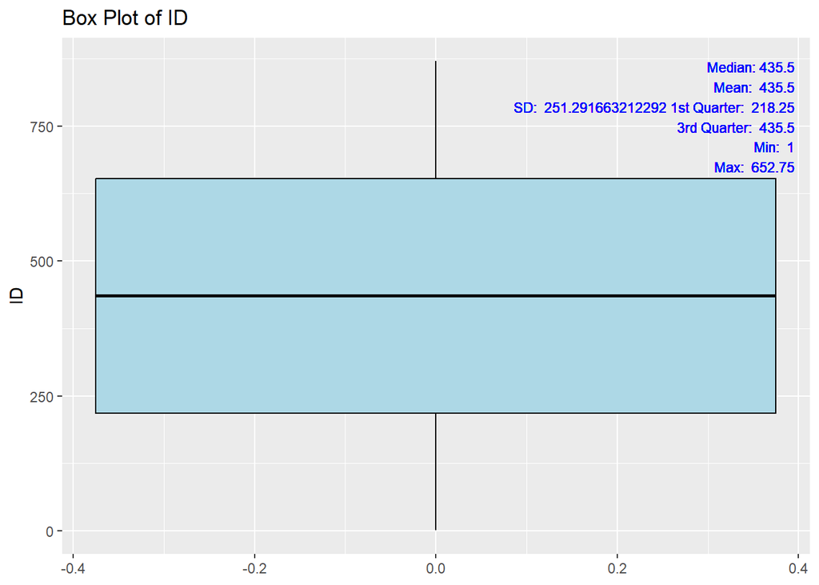

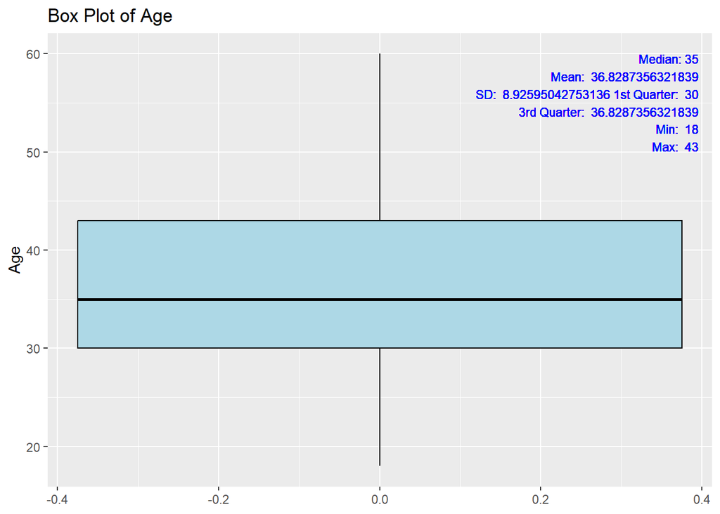

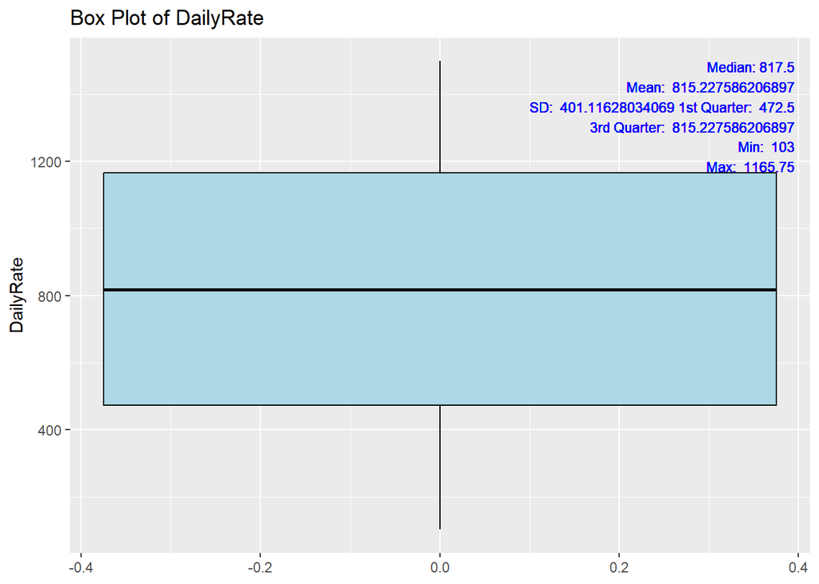

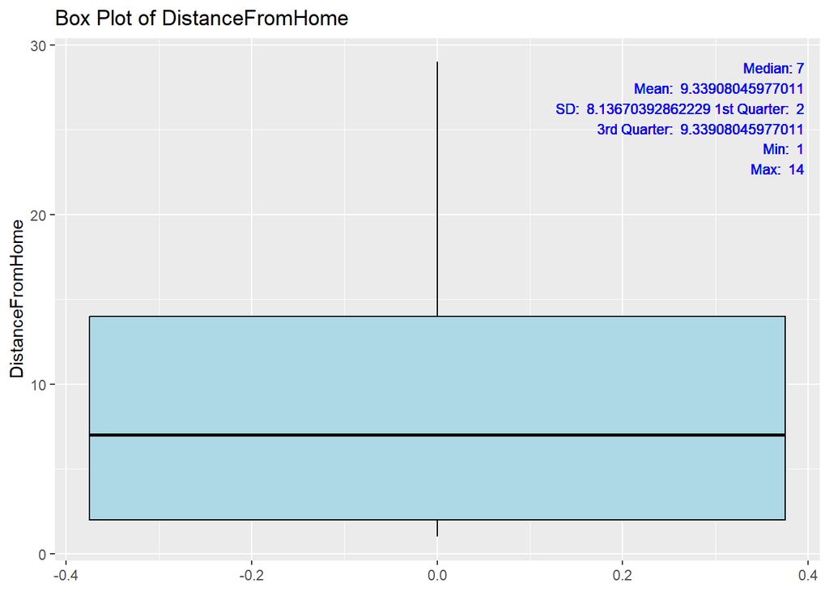

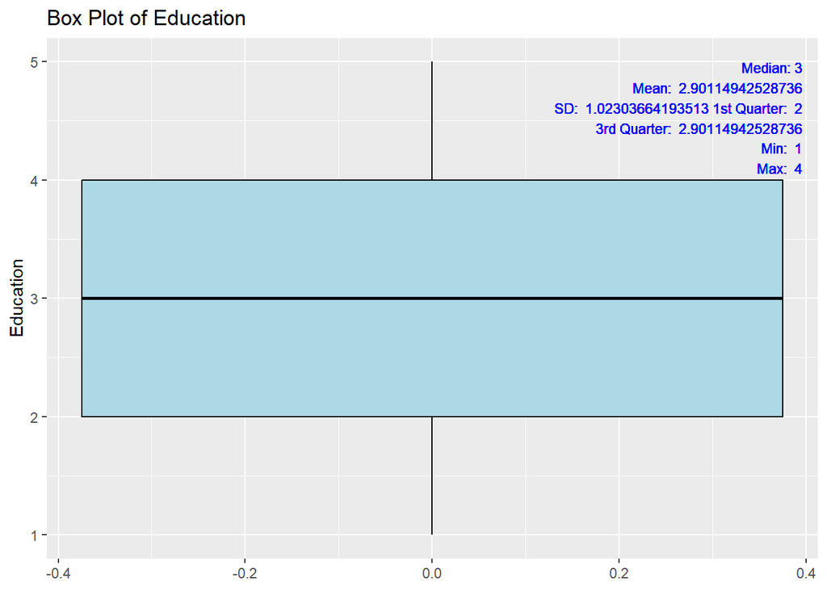

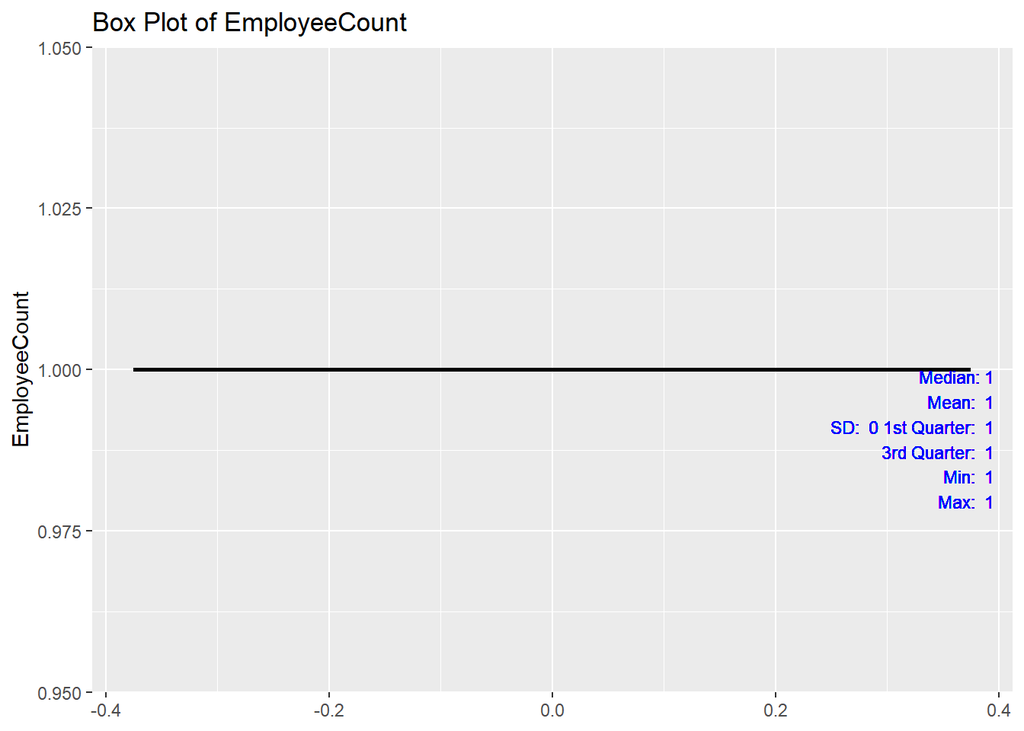

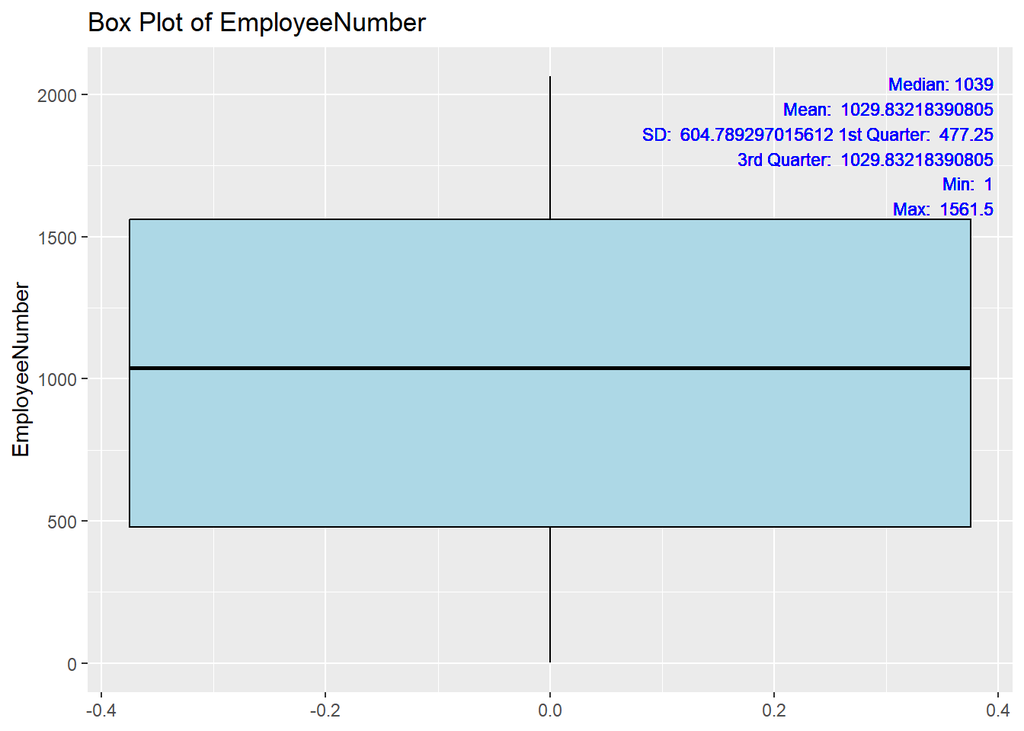

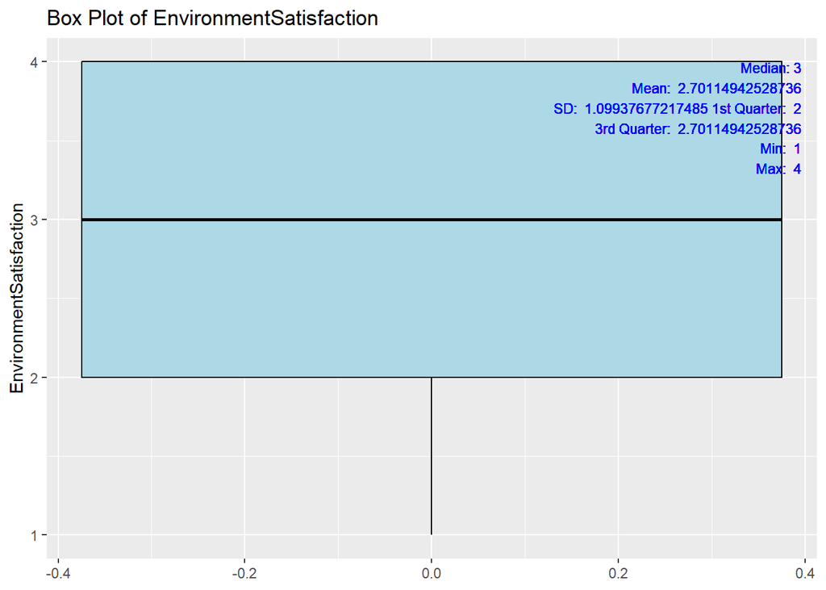

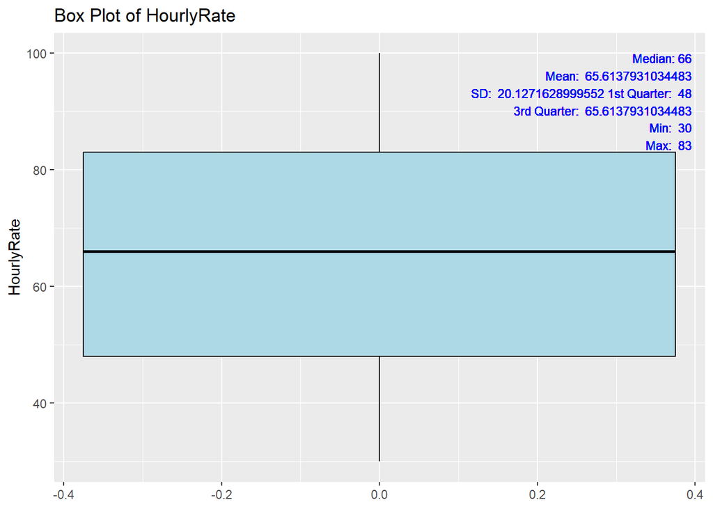

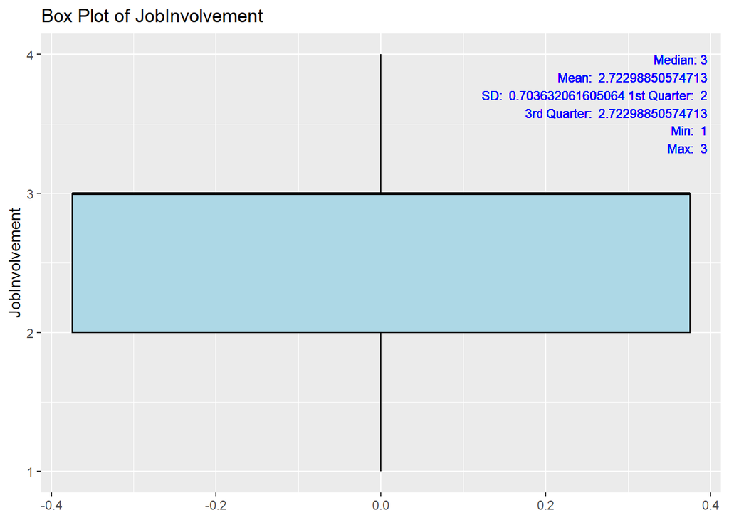

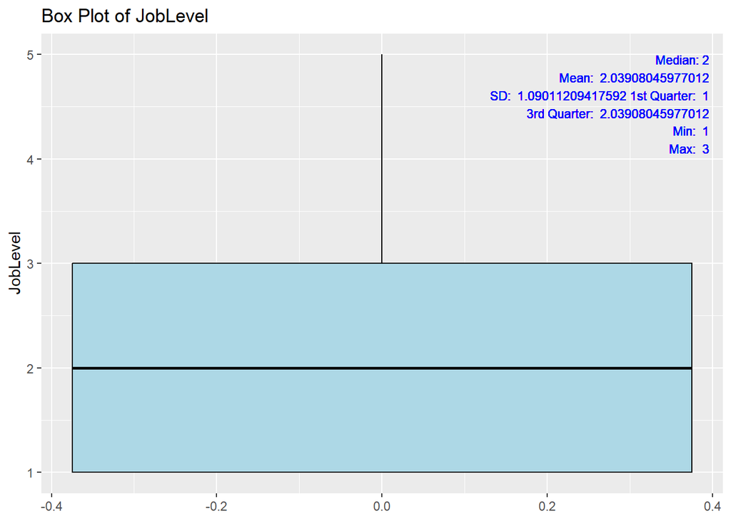

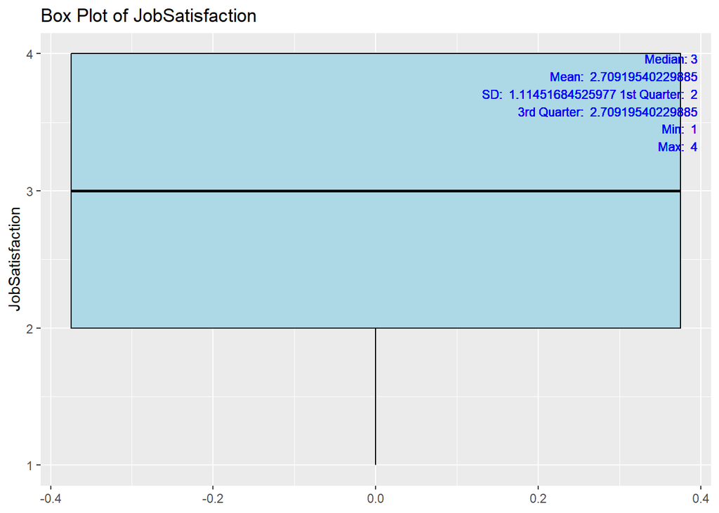

[16 more figures not shown]

```r
# Since the variables are a lot, and i plan on saving time, I plan using a for loop to iterate through the variables and plot their box plots to visualize their summary statistics



for (Variable in names(Talent_Train)){
  # Check if the column is numeric
  if (is.numeric(Talent_Train[[Variable]])) {
    # Create a box plot for numeric variables
   plot <-  ggplot(Talent_Train, aes_string(x = , y = Variable)) +
      geom_boxplot(color = "black", fill = "lightblue") +
      labs(title = paste("Box Plot of", Variable)) +
      geom_text(aes(label = paste("Median:", median(Talent_Train[[Variable]]), "\n",
                                  "Mean: ", mean(Talent_Train[[Variable]]), "\n",
                                  "SD: ", sd(Talent_Train[[Variable]]),
                                  "1st Quarter: ", summary(Talent_Train[[Variable]])[2], "\n",
                                  "3rd Quarter: ", summary(Talent_Train[[Variable]])[4], "\n",
                                  "Min: ", summary(Talent_Train[[Variable]])[1], "\n",
                                  "Max: ", summary(Talent_Train[[Variable]])[5], "\n")),
                x = 0.4, y = max(Talent_Train[[Variable]]), hjust = 1, vjust = 1, size = 3, color = "blue")

   # Print the plot
    print(plot)
  }
}
```

From the box plots, 4 variables have really bad spread of data. They are : EmployeeCount, Over_18_Binary, PerformanceRating, and StandardHours

## VISUALIZING THE VARIABLEs INTERACTIONS WITH THE RESPONSE VARIABLE (MONTHLY INCOME)

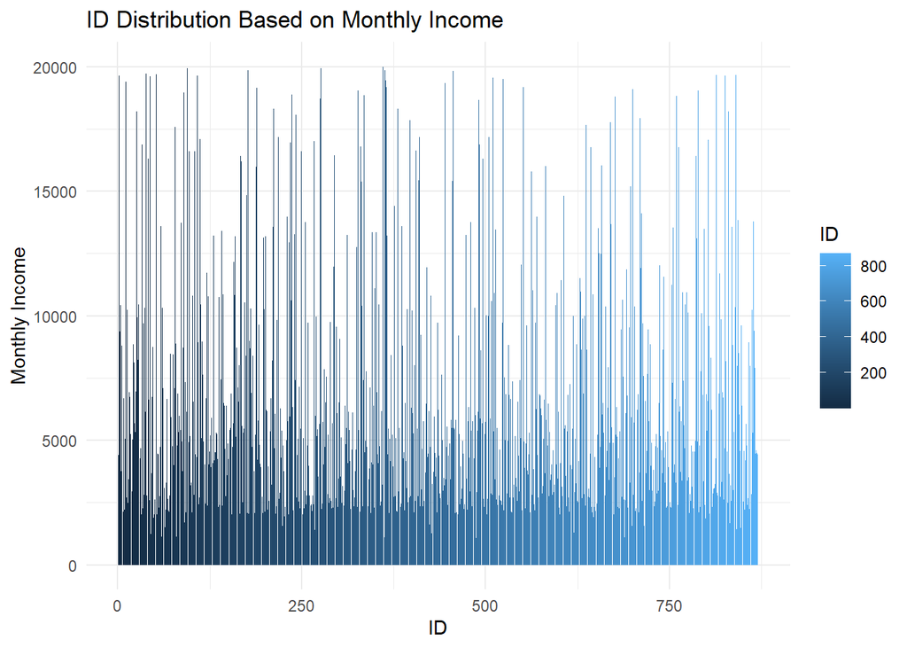

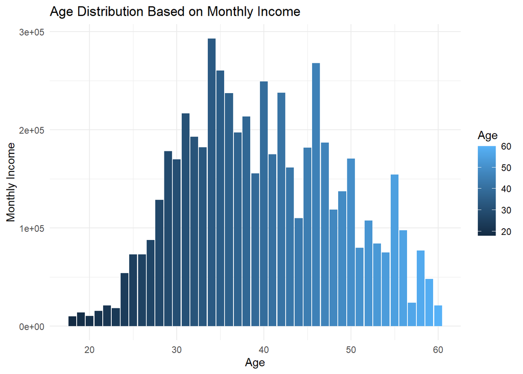

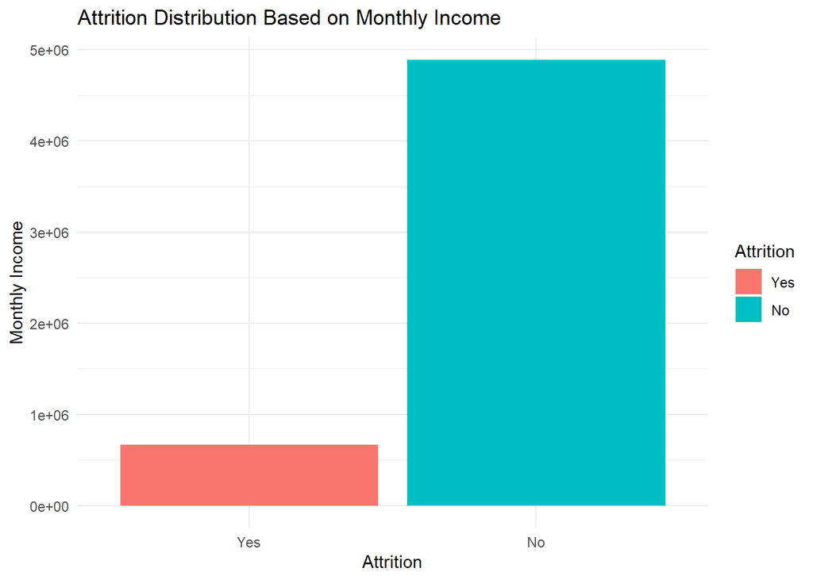

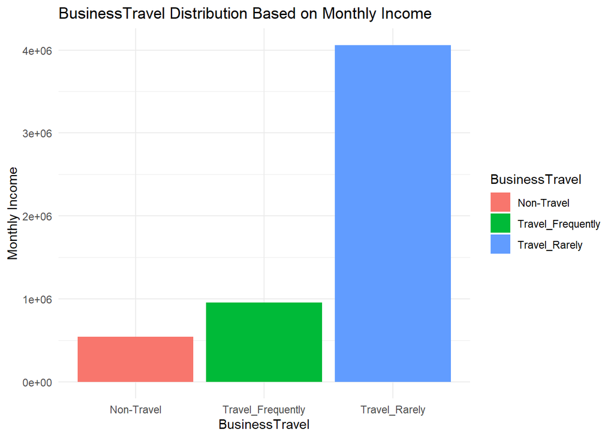

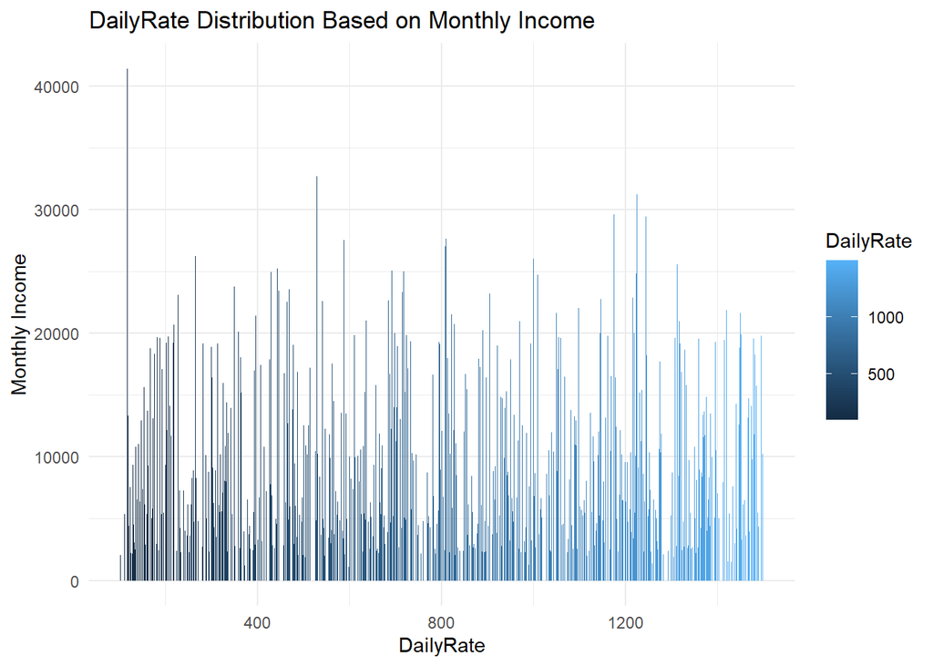

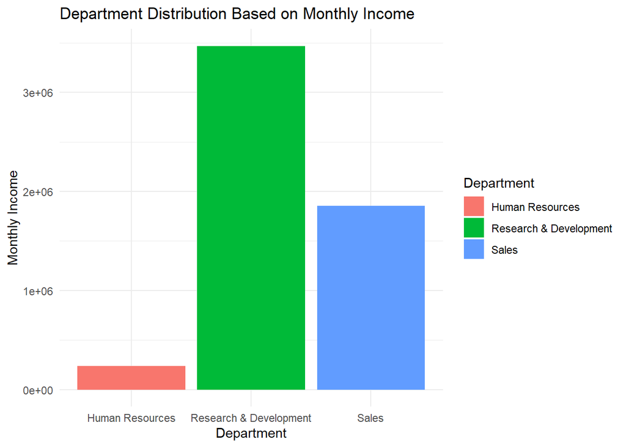

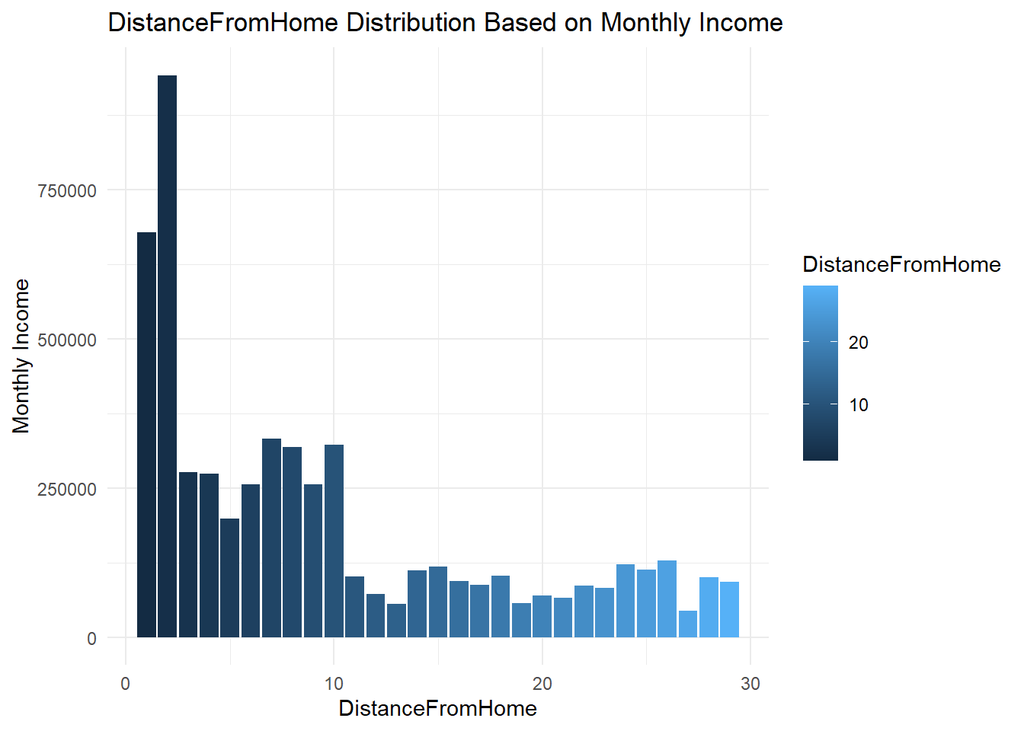

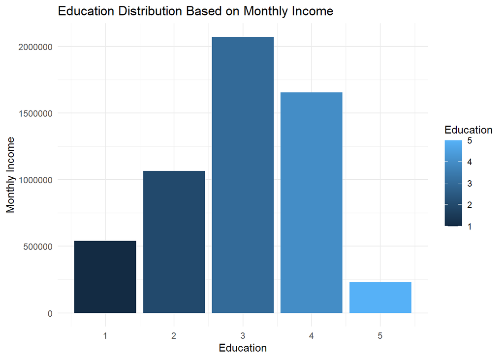

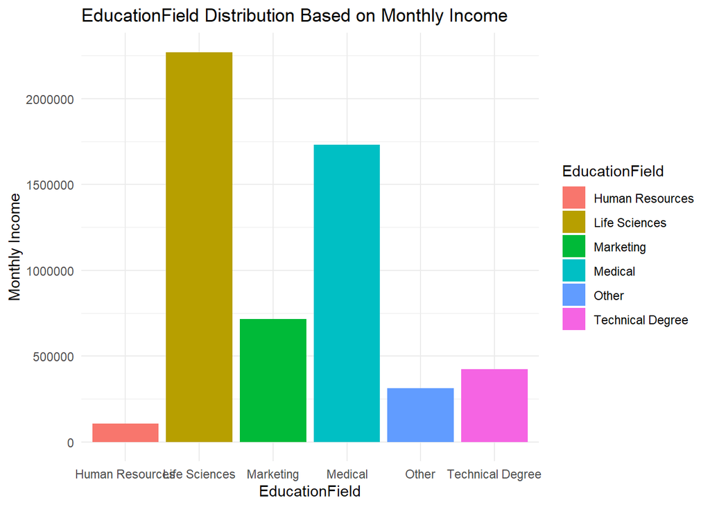

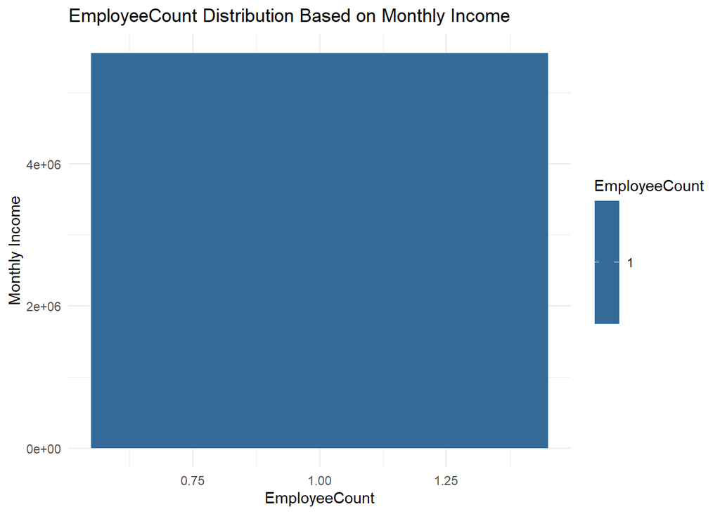

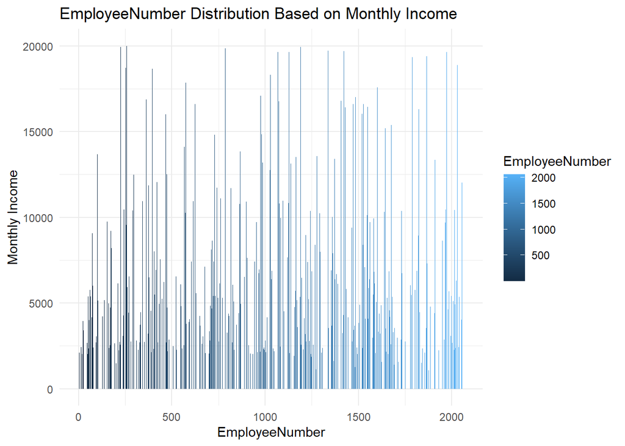

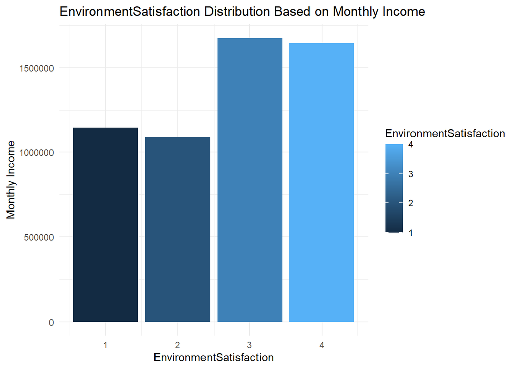

[23 more figures not shown]

```r
# Since the variables are a lot, and i plan on saving time, I plan using a for loop to iterate through the variables and plot their bar plots to visualize their EDA

# Iterate through the dataset and execute the plot command
for (Variable in names(Talent_Train)){
  # Check if the column is numeric
  if (!(Variable == "MonthlyIncome")) {

    # Construct the bunch of commands with the current variable

  command <- paste0(
    "Talent_Train %>% ggplot(aes(x=", Variable, ",y= MonthlyIncome, fill = ", Variable, ")) + geom_bar(stat='identity')  + \n",
    "ylab('Monthly Income') + xlab('", Variable, "') + ggtitle('", Variable, " Distribution Based on Monthly Income') + theme_minimal() \n"
  )

    # Execute the command
    plot <- eval(parse(text = command))

    print(plot)
  }
}
```

- Employees in Job Level 2 seems to be paid the best - Sales Executive seems to be the highest paid in the company. - The employees with around 10 years seem to be paid the highest. - Employees with Job involvement rate of 3 are the highest paid in the company. - The employees with Stock option level 1 seem to have the highest monthly salary. - Human Resources Employees seem to be the lowest paid

#### LOOKING AT THE PVALUE DISTRIBUTIONS FOR THE MONTHLY INCOME

Looking at how each variable in the model, significantly impacts our response variable (MonthlyIncome)

```r
model <-lm(MonthlyIncome ~ ., data = Talent_Train)

# Extract variable names
variable_names <- rownames(summary(model)$coefficients)

# getting the  p-values from the model3
p_values <- summary(model)$coefficients[, 4]  # Assuming p-values are in the 4th column of the summary table
p_values <- data.frame(p_values)$p_values

df <- data.frame(variable_names, p_values) #combining the pvalues and variable names into a dataframe

df <- df[!df$p_value == 0 , ] #removing varaiables with pvalue = 0
df$p_values <- log(df$p_values)  * -1

# Rank p-values in the dataset from max to min
df$rank <- rank(-df$p_value)

sorted_df <- df[order(df$rank), ]

sorted_df
```

```
##                      variable_names     p_values rank
## 22                         JobLevel 355.50839712    1
## 27         JobRoleResearch Director 147.27554033    2
## 25                   JobRoleManager 103.71500561    3
## 41                TotalWorkingYears  12.35695622    4
## 24     JobRoleLaboratory Technician   7.38850243    5
## 6       BusinessTravelTravel_Rarely   6.21230807    6
## 28        JobRoleResearch Scientist   3.19931378    7
## 46          YearsSinceLastPromotion   3.11440399    8
## 38                PerformanceRating   3.09295539    9
## 34                      MonthlyRate   2.73419587   10
## 37                PercentSalaryHike   2.27934762   11
## 47             YearsWithCurrManager   2.23296225   12
## 7                         DailyRate   2.18870241   13
## 2                                ID   2.18290967   14
```

[output cut: 33 more lines]

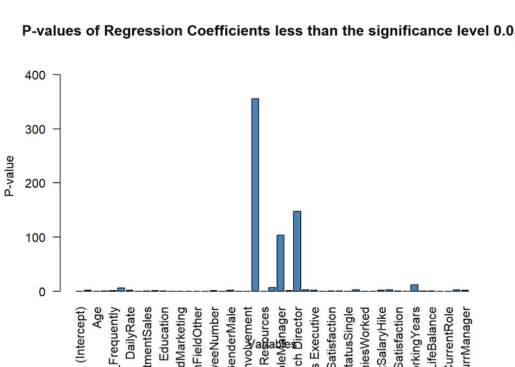

```r
barplot(df$p_values,
        main = "P-values of Regression Coefficients less than the significance level 0.05",
        xlab = "Variables",
        ylab = "P-value",
        names.arg = df$variable_names,
        las = 2,  # Rotate x-axis labels vertically for better readability
        col = "steelblue",  # Set color of bars
        ylim = c(exp(0.05) * -1, max(sorted_df$p_values) * 1.2)  # Set ylim from the significance level to the max p-values

)
```

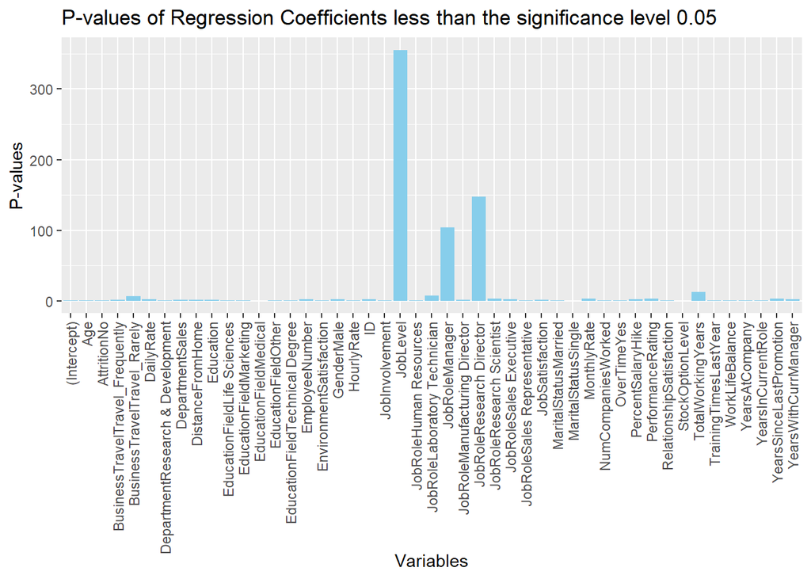

```r
library(ggplot2)
ggplot(sorted_df,aes(variable_names,p_values, fill = ifelse(p_values > (exp(0.05) * -1), "Positive", "Negative"))) + #filtering just the highly significant p-values
  geom_bar(stat="identity", fill = "skyblue") +
  #geom_text(aes(label = variable_names), vjust = -0.5) +  # Add text labels on top of bars
  scale_fill_manual(values = c("Positive" = "skyblue", "Negative" = "salmon")) +
  labs(x = "Variables", y = "P-values", title = "P-values of Regression Coefficients less than the significance level 0.05") +
  theme(axis.text.x = element_text(angle = 90, vjust = 0.5, hjust=1))  # Rotate x-axis labels for better readability
```

From the plot above, we can see that the top 5 highly significant values with respect to the response variable y in terms of its relative most significant to least significant variables are JobLevel, JobRole, TotalWorkingYears, BusinessTravel, YearsSinceLastPromotion

#### GETTING THE FIRST VARIABLE

Im looking for the perfect (MonhlyIncome ~ dependent variable) combination to get the minimum RMSE

```r
# FORWARD SELECTION # 1
set.seed(21)
vars <- names(Talent_Train)
vars <- vars[vars != "MonthlyIncome"] #iterating thru variables that are not "MonthlyIncome"
vars <- vars[vars != "Attrition"] #iterating thru variables that are not "Attrition"
num_vars <- length(vars)
var_rmse <- data.frame("vars" = vars)
num_folds <- 10
for (j in 1:num_vars) {
  var <- vars[j]
  #print(var)
  folds <- createFolds(Talent_Train$MonthlyIncome, k = num_folds)
  rmse_scores <- numeric(num_folds)
  for (i in 1:num_folds) {
    #using the train data
    train_indices <- unlist(folds[-i])
    test_indices <- unlist(folds[i])
    train <- Talent_Train[train_indices, ]
    test <- Talent_Train[test_indices, ]
    form <- as.formula(paste("MonthlyIncome ~ ",var,sep=""))
    model <-lm(form, data = train) #fit a linear regression model
    predictions <- predict(model, newdata = test) #Make Predictiions
    residuals <- predictions - test$MonthlyIncome # Calculate residuals
    rmse <- sqrt(mean(residuals^2)) # Compute RMSE
    rmse_scores[i] <- rmse
  }
  var_rmse$rmse[var_rmse$var == var] <- mean(rmse_scores)
}

min_rmse = min(var_rmse$rmse) #finding the max_rmse
min_rmse_variable <- var_rmse$vars[which.min(var_rmse$rmse)]

#printing out rresult
cat("optimum Variable is ", min_rmse_variable, " with a minimum rmse of ", min_rmse)
```

```
## optimum Variable is  JobLevel  with a minimum rmse of  1409.276
```

optimum Variable is JobLevel with a minimum rmse of 1409.276

#### GETTING THE SECOND VARIABLE

Next ill look for the optimumm variable to add to our regression model (Monthly ~ JobLevel) in order to provide the minimum rmse

```r
# FORWARD SELECTION # 2
set.seed(21)
vars <- names(Talent_Train)
vars <- vars[vars != "MonthlyIncome"] #iterating thru variables that are not "MonthlyIncome"
vars <- vars[vars != "Attrition"] #iterating thru variables that are not "Attrition"
vars <- vars[vars != "JobLevel"] #iterating thru variables that are not "JobeLevel"
num_vars <- length(vars)
var_rmse <- data.frame("vars" = vars)
num_folds <- 10
for (j in 1:num_vars) {
  var <- vars[j]
  #print(var)
  folds <- createFolds(Talent_Train$MonthlyIncome, k = num_folds)
  rmse_scores <- numeric(num_folds)
  for (i in 1:num_folds) {
    #using the train data
    train_indices <- unlist(folds[-i])
    test_indices <- unlist(folds[i])
    train <- Talent_Train[train_indices, ]
    test <- Talent_Train[test_indices, ]
    form <- as.formula(paste("MonthlyIncome ~ JobLevel +  ",var,sep=""))
    model <-lm(form, data = train) #fit a linear regression model
    predictions <- predict(model, newdata = test) #Make Predictiions
    residuals <- predictions - test$MonthlyIncome # Calculate residuals
    rmse <- sqrt(mean(residuals^2)) # Compute RMSE
    rmse_scores[i] <- rmse
  }
  var_rmse$rmse[var_rmse$var == var] <- mean(rmse_scores)
}

min_rmse = min(var_rmse$rmse) #finding the max_rmse
min_rmse_variable <- var_rmse$vars[which.min(var_rmse$rmse)]

cat("optimum Variable is ", min_rmse_variable, " with a minimum rmse of ", min_rmse)
```

```
## optimum Variable is  JobRole  with a minimum rmse of  1085.182
```

optimum Variable is JobRole with a minimum rmse of 1085.182

#### GETTING THE THIRD VARIABLE

Next ill look for the optimumm variable to add to our regression model (Monthly ~ JobLevel + JobRole) in order to provide the minimum rmse

```r
# FORWARD SELECTION # 3
set.seed(21)
vars <- names(Talent_Train)
vars <- vars[vars != "MonthlyIncome"] #iterating thru variables that are not "MonthlyIncome"
vars <- vars[vars != "Attrition"] #iterating thru variables that are not "Attrition"
vars <- vars[vars != "JobLevel"] #iterating thru variables that are not "JobeLevel"
vars <- vars[vars != "JobRole"] #iterating thru variables that are not "JobRole"
num_vars <- length(vars)
var_rmse <- data.frame("vars" = vars)
num_folds <- 10
for (j in 1:num_vars) {
  var <- vars[j]
  #print(var)
  folds <- createFolds(Talent_Train$MonthlyIncome, k = num_folds)
  rmse_scores <- numeric(num_folds)
  for (i in 1:num_folds) {
    #using the train data
    train_indices <- unlist(folds[-i])
    test_indices <- unlist(folds[i])
    train <- Talent_Train[train_indices, ]
    test <- Talent_Train[test_indices, ]
    form <- as.formula(paste("MonthlyIncome ~ JobLevel +  JobRole + ",var,sep=""))
    model <-lm(form, data = train) #fit a linear regression model
    predictions <- predict(model, newdata = test) #Make Predictiions
    residuals <- predictions - test$MonthlyIncome # Calculate residuals
    rmse <- sqrt(mean(residuals^2)) # Compute RMSE
    rmse_scores[i] <- rmse
  }
  var_rmse$rmse[var_rmse$var == var] <- mean(rmse_scores)
}

min_rmse = min(var_rmse$rmse) #finding the max_rmse
min_rmse_variable <- var_rmse$vars[which.min(var_rmse$rmse)]

cat("optimum Variable is ", min_rmse_variable, " with a minimum rmse of ", min_rmse)
```

```
## optimum Variable is  TotalWorkingYears  with a minimum rmse of  1061.89
```

optimum Variable is TotalWorkingYears with a minimum rmse of 1061.89

#### TESTING THE RMSE WITH THE TEST DATASET

Next, ill test our optimum model, wit out dataset, splitting the dataset as test and train with a 70 - 30 split respectively.

```r
#splitting 70% - 30%
trainIndices = sample(seq(1:length(Talent_Train$Age)),round(.7*length(Talent_Train$MonthlyIncome))) #split is 70% and 30%
train = Talent_Train[trainIndices,] #train datset
test = Talent_Train[-trainIndices,] #test dataset

# Fit the linear regression model
model <- lm(MonthlyIncome ~ JobLevel + JobRole + TotalWorkingYears, data = train)

# Make predictions
predictions <- predict(model, newdata = test)

# Calculate residuals
residuals <- predictions - test$MonthlyIncome

# Compute RMSE
rmse <- sqrt(mean(residuals^2))

# Print RMSE
print(rmse)
```

```
## [1] 975.667
```

```r
test$predictions <- predictions

# Generation our regression for the test dataset
new_data <- test %>% select(predictions, ID)

new_data <- new_data[order(new_data$ID), ]

# Specify the file path where you want to save the file
file_path <- "Case2PredictionsOwolabi Salary.csv"

# Write the dataset to a CSV file
write.csv(new_data, file = file_path, row.names = FALSE)

# Check if the file is created
file.exists(file_path)
```

```
## [1] TRUE
```

## PREDICTION MODEL WITH ATTRITION

Next, i will try finding the best variables for our predictive classification model with Attrition as ou response variable

## VISUALIZING THE CATEGORICAl VARIABLEs INTERACTIONS WITH THE RESPONSE VARIABLE (ATTRITION)

Looking at the Exploratory data analysis to visualize the relation ship between the attrition rate and other dependent variables